# Progetto di Foundations of Probability and Statistics: BodyFat

Marco Scatassi, Niccolò Puccinelli

7/11/2021

# ABSTRACT

Nel seguente progetto è presentata l’analisi del dataset “Bodyfat”. Lo scopo dell’analisi è quello di riuscire a prevedere la percentuale di grasso corporeo utilizzando misure fisiche facilmente ottenibili. Il dataset è esplorato e poi suddiviso in un training-set contente l’80% delle osservazioni iniziali, scelte casualmente, e in un test-set contenente il restante 20%. Successivamente, è effettuata un’analisi descrittiva del training-set, ponendo particolare attenzione alla correlazione fra le variabili in esso raccolte. Sono poi sviluppati diversi modelli di regressione e confrontati.

# 1. Descrizione del dataset

- Density determined from underwater weighing
- Percent body fat from Siri’s (1956) equation (variabile **target**)
- Age (years)
- Weight (lbs)
- Height (inches)
- Neck circumference (cm)
- Chest circumference (cm)
- Abdomen circumference (cm)
- Hip circumference (cm)
- Thigh circumference (cm)
- Knee circumference (cm)
- Ankle circumference (cm)
- Biceps (extended) circumference (cm)
- Forearm circumference (cm)
- Wrist circumference (cm)

La percentuale di bodyfat è calcolata a partire dalla variabile *Density* mediante la seguente equazione:

$\%$ $BodyFat$ $=$ $(\frac{495}{Density}) - 450$

Sussiste perciò una relazione lineare diretta tra *BodyFat* e $Density^{-1}$, rendendo dunque l’utilizzo di *Density* come variabile esplicativa in un modello di regressione non significativo. *Density* verrà comunque impiegata ai fini di un confronto con il modello di regressione costituito dalle variabili concernenti le misurazioni fisiche.

# 2. Librerie utilizzate

Sono state impiegate le seguenti librerie:

- *fBasics*: funzione *basicStats* per un sommario dei principali valori statistici.
- *tidyverse*: package contenente varie utilities grafiche e organizzative. Nello specifico:
  - *ggplot2*: libreria per la creazione e la manipolazione di grafici.
  - *dplyr*: libreria per la gestione dei dati.
- *gridExtra*: funzione *grid.arrange* per la presentazione multipla di grafici creati con *ggplot2*.
- *ggpubr*: libreria contenente ulteriori utilities grafiche e testuali.
- *corrplot*: libreria impiegata per la creazione dei grafici di correlazione.
- *MASS*: libreria contenente la funzione *stepAIC*, la quale effettua una selezione *stepwise* del modello.
- *lindia*: funzione *gg_qplot* per una migliore visualizzazione del Normal-QQ Plot.
- *knitr*: libreria contenente utilities per la visualizzazione grafica delle tabelle in R-Markdown.

# 3. Analisi descrittiva

## 3.1 Apertura file e gestione variabili

Per comodità interpretativa cambiamo l’unità di misura delle variabili *Height* (da inches a cm) e *Weight* (da lbs a kg).

Dopo la modifica delle variabili il dataset si presenta nella seguente forma:

| Density | BodyFat | Age | Weight | Height | Neck | Chest | Abdomen | Hip | Thigh | Knee | Ankle | Biceps | Forearm | Wrist |
| --- | --- | --- | --- | --- | --- | --- | --- | --- | --- | --- | --- | --- | --- | --- |
| 1.0708 | 12.3 | 23 | 69.96671 | 172.085 | 36.2 | 93.1 | 85.2 | 94.5 | 59.0 | 37.3 | 21.9 | 32.0 | 27.4 | 17.1 |
| 1.0853 | 6.1 | 22 | 78.58497 | 183.515 | 38.5 | 93.6 | 83.0 | 98.7 | 58.7 | 37.3 | 23.4 | 30.5 | 28.9 | 18.2 |
| 1.0414 | 25.3 | 22 | 69.85331 | 168.275 | 34.0 | 95.8 | 87.9 | 99.2 | 59.6 | 38.9 | 24.0 | 28.8 | 25.2 | 16.6 |
| 1.0751 | 10.4 | 26 | 83.80129 | 183.515 | 37.4 | 101.8 | 86.4 | 101.2 | 60.1 | 37.3 | 22.8 | 32.4 | 29.4 | 18.2 |
| 1.0340 | 28.7 | 24 | 83.57449 | 180.975 | 34.4 | 97.3 | 100.0 | 101.9 | 63.2 | 42.2 | 24.0 | 32.2 | 27.7 | 17.7 |
| 1.0502 | 20.9 | 24 | 95.36791 | 189.865 | 39.0 | 104.5 | 94.4 | 107.8 | 66.0 | 42.0 | 25.6 | 35.7 | 30.6 | 18.8 |

## 3.2 Individuazione e rimozione di valori nulli e anomali

Il dataset non presenta valori nulli:

|  | Density | BodyFat | Age | Weight | Height | Neck | Chest | Abdomen | Hip | Thigh | Knee | Ankle | Biceps | Forearm | Wrist |
| --- | --- | --- | --- | --- | --- | --- | --- | --- | --- | --- | --- | --- | --- | --- | --- |
| Nan | 0 | 0 | 0 | 0 | 0 | 0 | 0 | 0 | 0 | 0 | 0 | 0 | 0 | 0 | 0 |

Per individuare i valori anomali procediamo come segue:

- Si grafica lo scatterplot tra $Density^{-1}$ e *BodyFat*. In virtù della relazione precedente i punti dovrebbero essere sostanzialmente allineati in modo tale da formare una retta;
- Si controllano i box plot associati a ciascuna variabile.

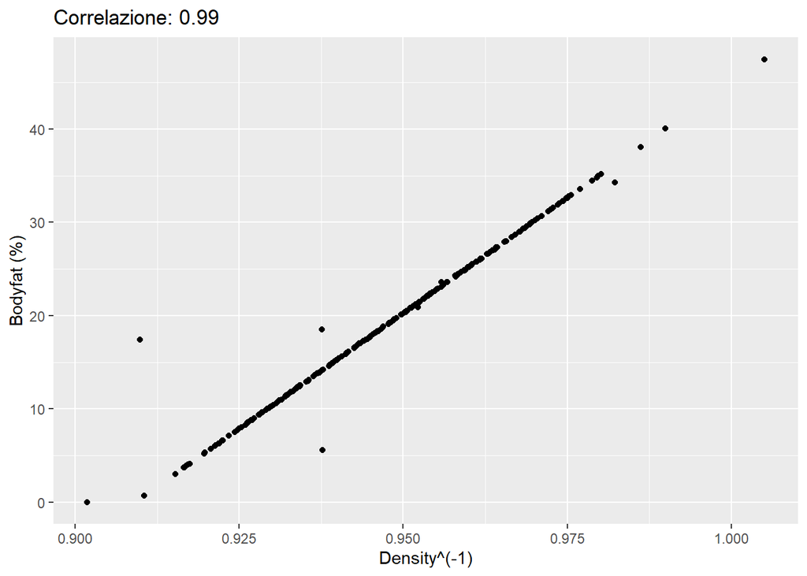

Dal grafico emergono 4 osservazioni anomale che risultano essere:

- 48
- 76
- 96
- 182

Si procede quindi alla loro rimozione.

```r
bodyfat <- bodyfat[-c(48, 76, 96, 182), ]
```

Consideriamo i box plot di Height, Weight e Ankle.

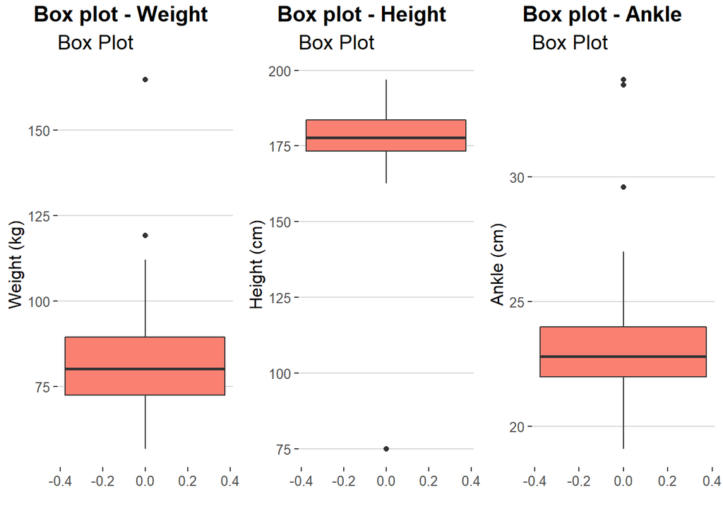

Si verifica che vi sono quattro osservazioni estremamente anomale, ossia quelle relative a:

- soggetto con Height circa uguale a 75cm
- soggetto con Weight circa uguale a 160Kg
- soggetti con Ankle circa uguale a 35cm

Procediamo dunque alla loro rimozione.

```r
bodyfat <- bodyfat %>% dplyr::filter(Height >= 100)
bodyfat <- bodyfat %>% dplyr::filter(Weight < 160)
bodyfat <- bodyfat %>% dplyr::filter(Ankle < 30)
```

Verifichiamo i box plot delle restanti variabili.

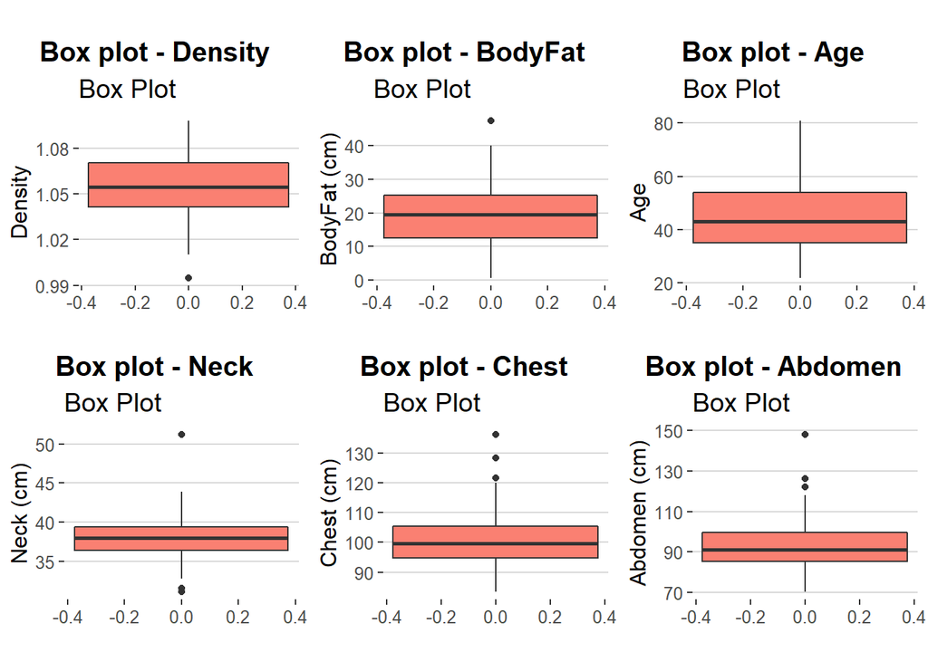

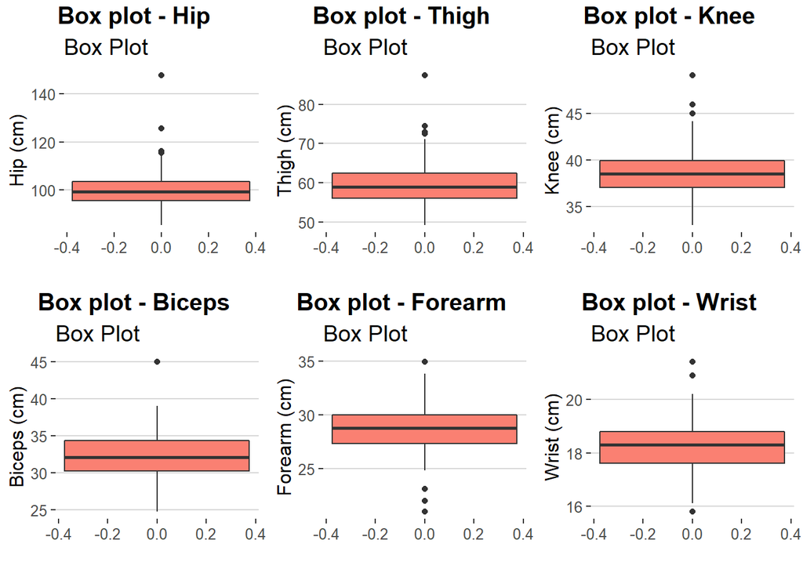

Dai precedenti non si riscontrano altre osservazioni così anomale da poter influenzare negativamente il modello di regressione e che quindi è utile rimuovere.

## 3.4 Analisi a un fattore

Prima di studiare in dettaglio le correlazioni tra le variabili del dataset, in particolare quelle con la variabile target, si indaga se vi sia o meno dipendenza in media fra l’età dei soggetti e BodyFat.

In particolare si aggiunge una colonna *Fascia_età* che ha tre modalità:

- Giovane (Age <= 30)
- Adulto (30< Age < 60)
- Anziano (Age >= 60)

e si cerca se in media il BodyFat sia o meno influenzato dall’appartenenza ad una certa fascia.

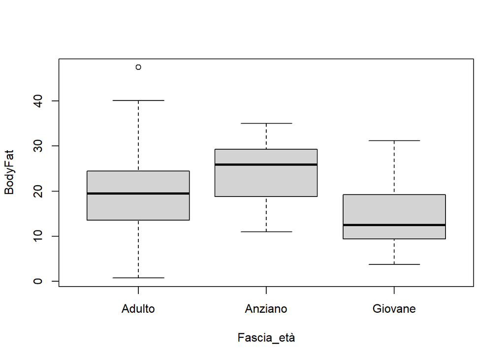

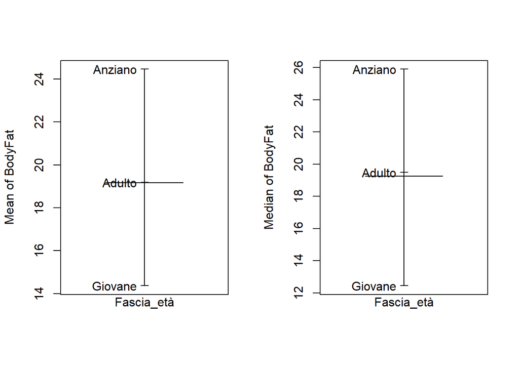

Come si osserva dai grafici precedenti sia la media che la mediana di BodyFat sono le più alte in corrispondenza della fascia *Anziano* mentre risultano le più basse per la fascia *Giovane*. La variabilità entro i gruppi sembra comparabile come si deduce anche dal test di Bartlett.

```r
bartlett.test(bodyfat_order_age$BodyFat,bodyfat_order_age$Fascia_età)
```

```
##
##  Bartlett test of homogeneity of variances
##
## data:  bodyfat_order_age$BodyFat and bodyfat_order_age$Fascia_età
## Bartlett's K-squared = 2.6151, df = 2, p-value = 0.2705
```

Prima di procedere con l’analisi della varianza a un fattore verifichiamo la normalità dei dati nei vari gruppi mediante l’uso di *qqnorm* e dei valori di skewness e kurtosis.

|  | BodyFat_Giovane | BodyFat_Adulto | BodyFat_Anziano |
| --- | --- | --- | --- |
| skewness | 0.536999 | 0.278809 | -0.519809 |
| kurtosis | -0.605540 | 0.051823 | -0.757190 |

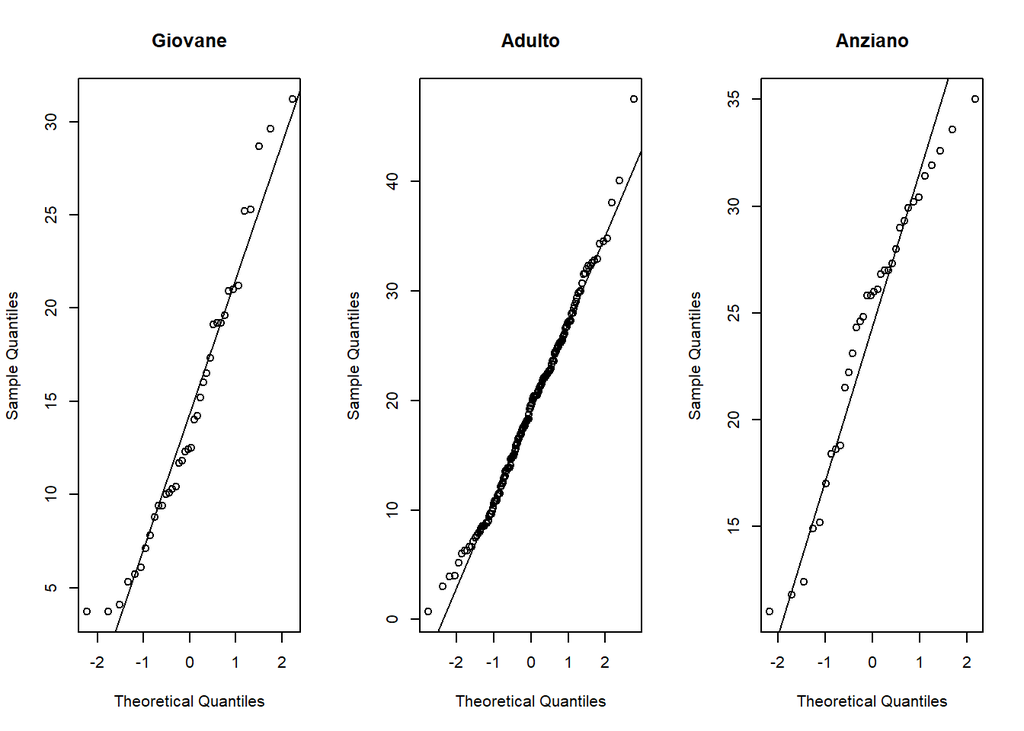

I valori in tabella, di skewness e kurtosis, i qqplot e quanto già detto sulla varianza dei gruppi, mostrano come le ipotesi di normalità e omoschedasticità siano applicabili.

Considerazioni del tutto analoghe alle precedenti possono essere fatte osservando il grafico seguente, nel quale in particolare, sono riportate le funzioni di densità di BodyFat rispetto ai tre gruppi e i centri dei gruppi, nello scatterplot, che mostrano un andamento crescente al crescere della fascia di età.

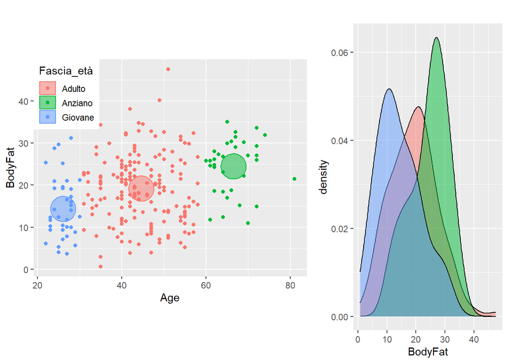

Procediamo dunque ad applicare il test di ipotesi a un fattore.

```r
oneway.test(bodyfat_order_age$BodyFat ~ bodyfat_order_age$Fascia_età, var.equal = TRUE)
```

```
##
##  One-way analysis of means
##
## data:  bodyfat_order_age$BodyFat and bodyfat_order_age$Fascia_età
## F = 15.046, num df = 2, denom df = 241, p-value = 6.959e-07
```

```r
qf(0.95,2,244)
```

```
## [1] 3.032816
```

I risultati precedenti portano al rifiuto dell’ipotesi nulla, il valore della statistica F calcolato è maggiore della soglia della regione critica.

Concludiamo quindi che vi è dipendenza in media tra la fascia di età e la percentuale di grasso corporeo.

## 3.5 Split train-test

Si divide ora il dataset in due parti: training-set (80%) e test-set (20%). La selezione viene effettuata in maniera casuale mediante la funzione *sample*.

```r
set.seed(123)
train = sample(1:nrow(bodyfat), size = 0.8 * nrow(bodyfat))
bodyfat.train = bodyfat[train, -c(16,17)]
bodyfat.test = bodyfat[-train, -c(16,17)]
```

## 3.6 Analisi descrittiva sul training set

Studiamo la variabile target BodyFat.

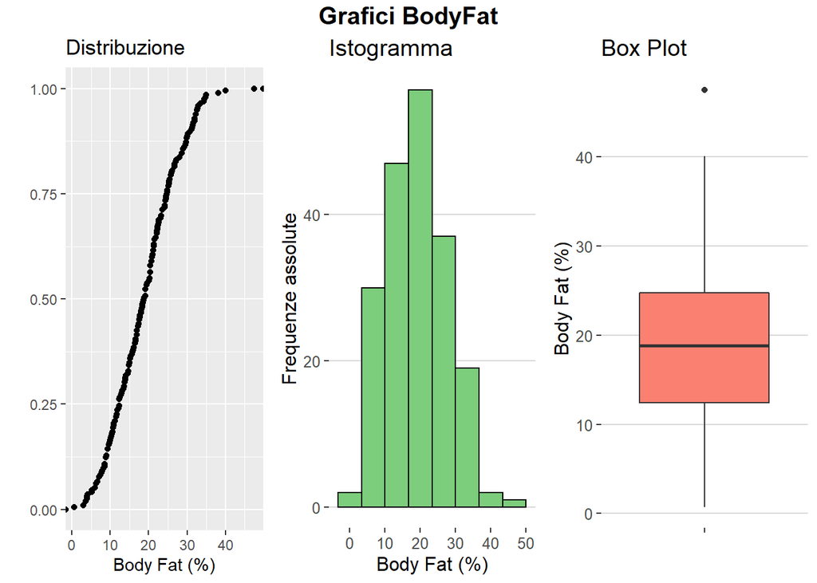

| basicStat | BodyFat |
| --- | --- |
| nobs | 195.000000 |
| NAs | 0.000000 |
| Minimum | 0.700000 |
| Maximum | 47.500000 |
| 1. Quartile | 12.400000 |
| 3. Quartile | 24.750000 |
| Mean | 19.037436 |
| Median | 18.800000 |
| Variance | 72.330499 |
| Stdev | 8.504734 |
| Skewness | 0.271326 |
| Kurtosis | -0.299559 |

Come si osserva dai grafici e dalla tabella riassuntiva delle statistiche principali, la variabile target risulta avere una distribuzione sostanzialmente simmetrica, anche la curtosi è molto vicina a zero. Sostanzialmente BodyFat si distribuisce come una normale. Ciò è anche giustificato dal qqplot e dal test di Shapiro-Wilks.

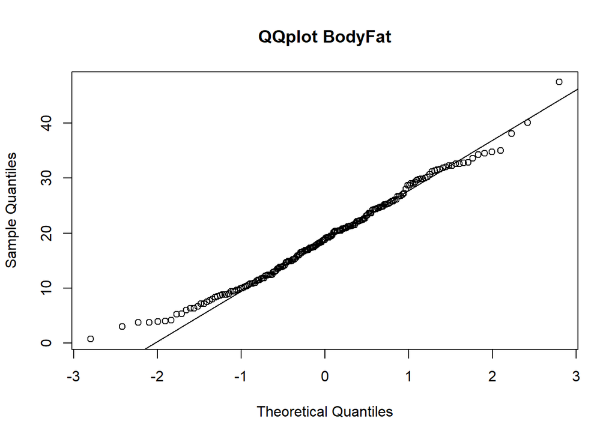

```r
shapiro.test(bodyfat.train$BodyFat)
```

```
##
##  Shapiro-Wilk normality test
##
## data:  bodyfat.train$BodyFat
## W = 0.98815, p-value = 0.104
```

Otteniamo un *p-value* di circa 0.1 > 0.05, quindi accettiamo l’ipotesi nulla.

Sono poi illustrati i grafici di dispersione tra *BodyFat* e le restanti variabili del dataset al fine di avere un’idea di quali siano le variabili maggiormente correlate a quella target.

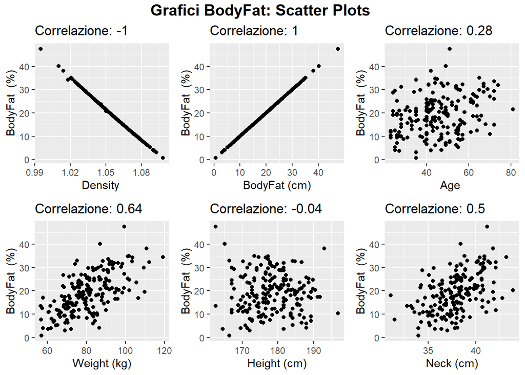

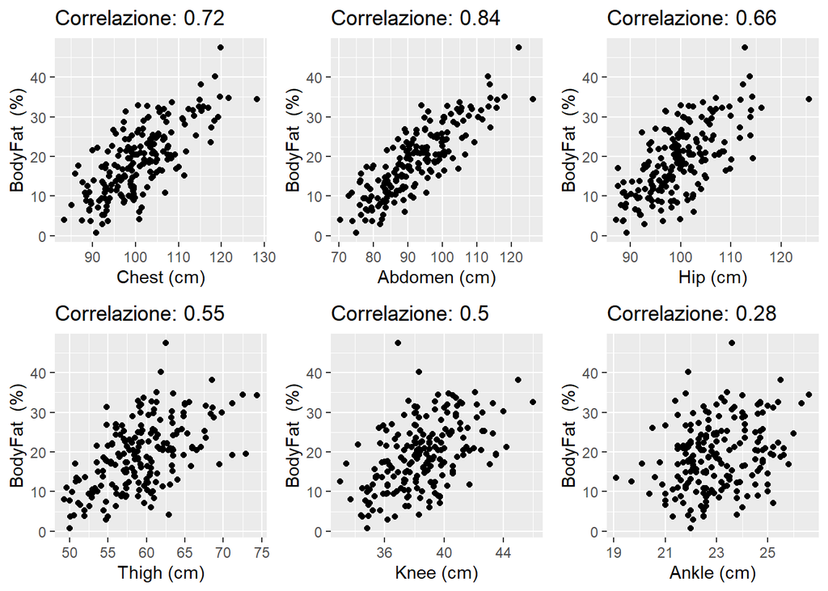

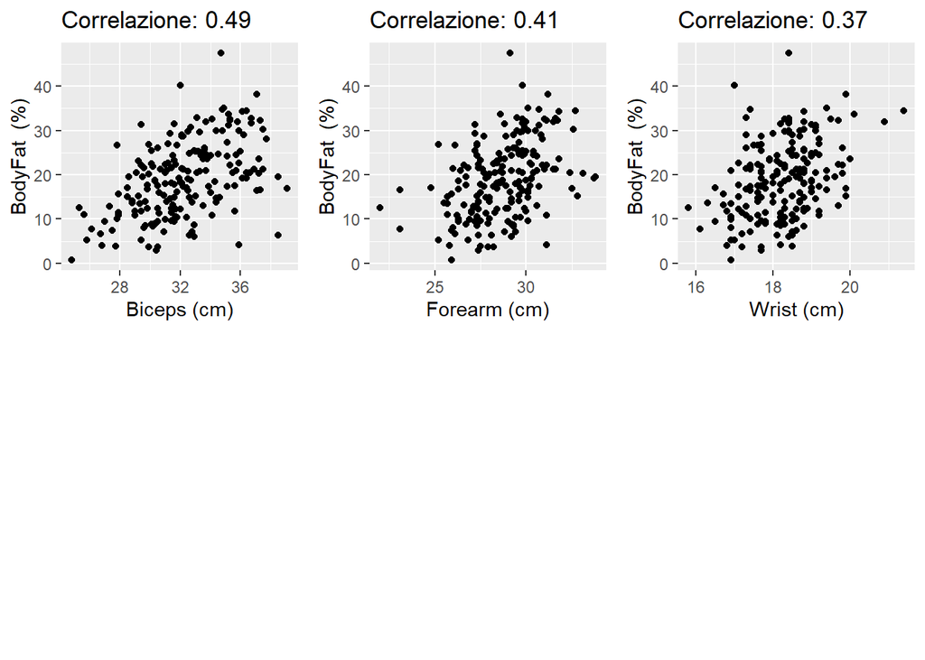

Possiamo per lo stesso motivo considerare la seguente rappresentazione grafica della matrice di correlazione.

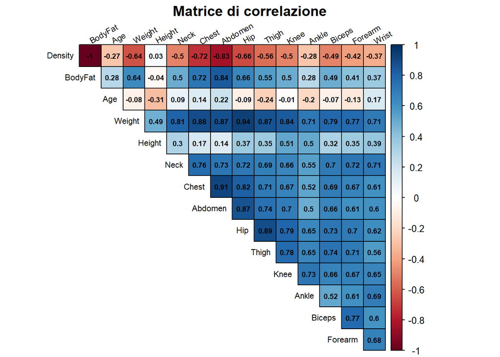

Analizzando la matrice di correlazione associata alle variabili identificate si osserva come queste siano molto correlate anche fra di loro.

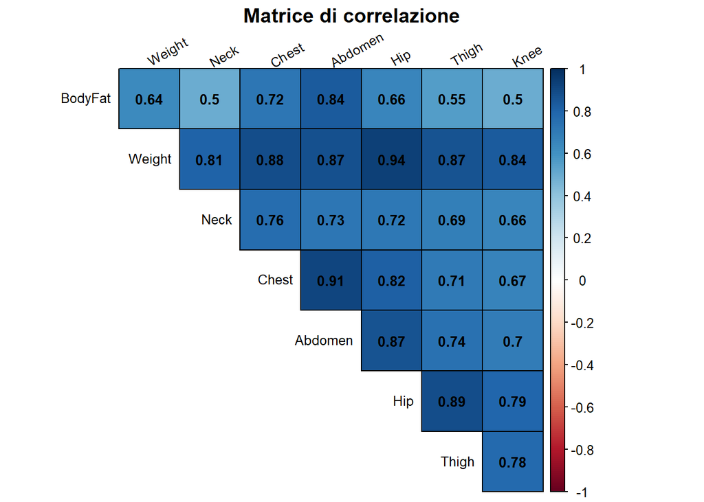

In particolare, ai fini di costruire un modello di regressione, risultano problematiche le correlazioni fra le prime 4 variabili più correlate a BodyFat.

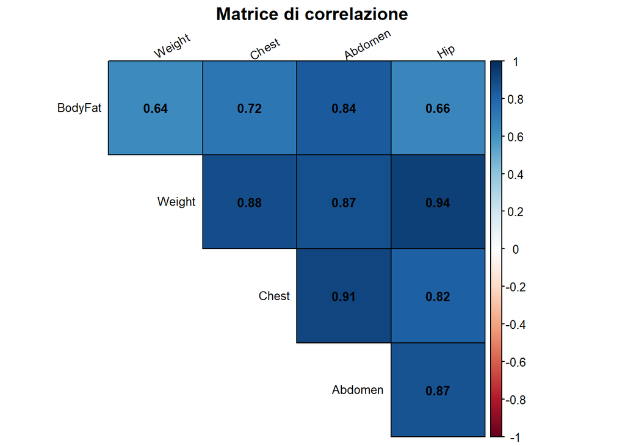

Cerchiamo ora di distinguere se la correlazione con la variabile target sia diretta o dovuta a qualche relazione tra le variabili interne, ossia se siamo o meno in presenza di correlazioni spurie.

Le tabelle seguenti riportano in seconda colonna i valori di correlazione parziale fra le variabili che nominano la colonna stessa, rispetto alla variabile sulla riga corrispondente.

|  | BodyFat-Abdomen |
| --- | --- |
| Weight | 0.7415155 |
| Chest | 0.6196598 |
| Hip | 0.7086126 |

|  | BodyFat-Weight |
| --- | --- |
| Chest | 0.0019561 |
| Abdomen | -0.3405591 |
| Hip | 0.0885973 |

|  | BodyFat-Chest |
| --- | --- |
| Weight | 0.4431360 |
| Abdomen | -0.1667437 |
| Hip | 0.4284247 |

|  | BodyFat-Hip |
| --- | --- |
| Weight | 0.2205946 |
| Chest | 0.1607500 |
| Abdomen | -0.2499986 |

Dalle tabelle precedenti si osserva come sostanzialmente solo la correlazione della variabile *Abdomen* con *BodyFat* sia poco influenzata dalla correlazione fra *Abdomen* e le altre variabili. Invece, la correlazione fra *Weight* e *BodyFat* può essere quasi totalmente spiegata da *Chest*, analogamente la correlazione fra *Chest* e *BodyFat* può essere quasi totalmente spiegata da *Abdomen* e la correlazione tra *Hip* e *BodyFat* dipende quasi interamente dalla correlazione tra *Hip* e le altre variabili.

# 4 REGRESSIONE LINEARE MUTLIPLA

## 4.1 Selezione delle variabili

Affrontiamo ora il problema di regressione lineare multipla a partire dalle considerazioni fatte in precedenza sulla correlazione fra le variabili del dataset.

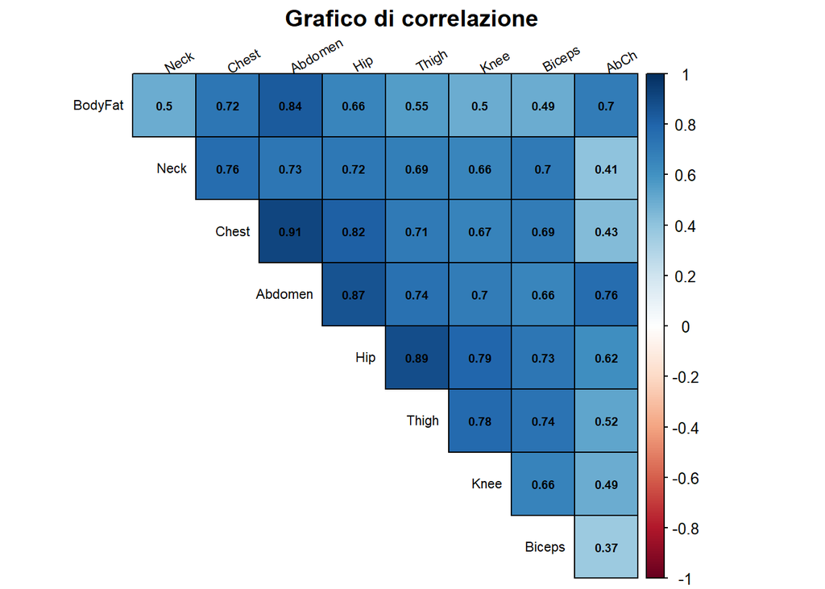

La variabile *AbCh* risulta molto correlata a *BodyFat* e il problema di multicollinearità è stato ridotto. Tuttavia, è possibile effettuare un’ulteriore selezione:

- *Abdomen* e *AbCh* sono ovviamente molto correlate. Rimuoviamo *Abdomen*;
- Dopo *Abdomen*, *Hip* è la covariata più correlata ad *AbCh* (e, in generale, alle altre covariate). Rimuoviamo anche *Hip*.

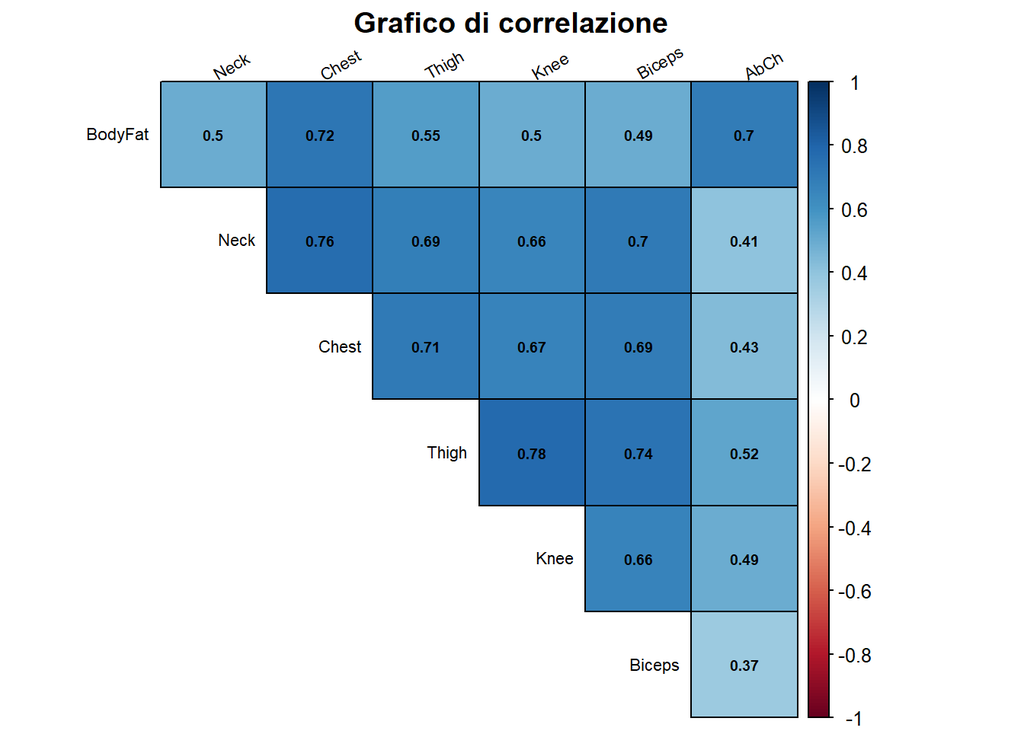

Sebbene continui a sussistere, il problema relativo alla multicollinearità è stato ridotto.

## 4.2 Il modello di regressione

Per la costruzione iniziale del modello di regressione impieghiamo le tre covariate più correlate a *BodyFat* (*AbCh*, *Chest* e *Thigh*), lasciando momentaneamente da parte *Neck*, *Knee* e *Biceps*.

Occupiamoci ora della scelta del modello di regressione. Impieghiamo dunque la funzione `stepAIC` per una selezione *stepwise* del modello, date le covariate *AbCh*, *Chest* e *Thigh* e la variabile target *BodyFat*.

```
##
## Call:
## lm(formula = BodyFat ~ Chest + Thigh + AbCh, data = bodyfat.train.1)
##
## Residuals:
##      Min       1Q   Median       3Q      Max
## -10.2771  -3.5001  -0.0223   3.3945  12.2501
##
## Coefficients:
##               Estimate Std. Error t value Pr(>|t|)
## (Intercept) -114.75839    6.53650 -17.557   <2e-16 ***
## Chest          0.63725    0.05805  10.978   <2e-16 ***
## Thigh         -0.24970    0.10012  -2.494   0.0135 *
## AbCh          92.14535    8.18060  11.264   <2e-16 ***
## ---
## Signif. codes:  0 '***' 0.001 '**' 0.01 '*' 0.05 '.' 0.1 ' ' 1
##
## Residual standard error: 4.575 on 191 degrees of freedom
## Multiple R-squared:  0.7151, Adjusted R-squared:  0.7106
## F-statistic: 159.8 on 3 and 191 DF,  p-value: < 2.2e-16
```

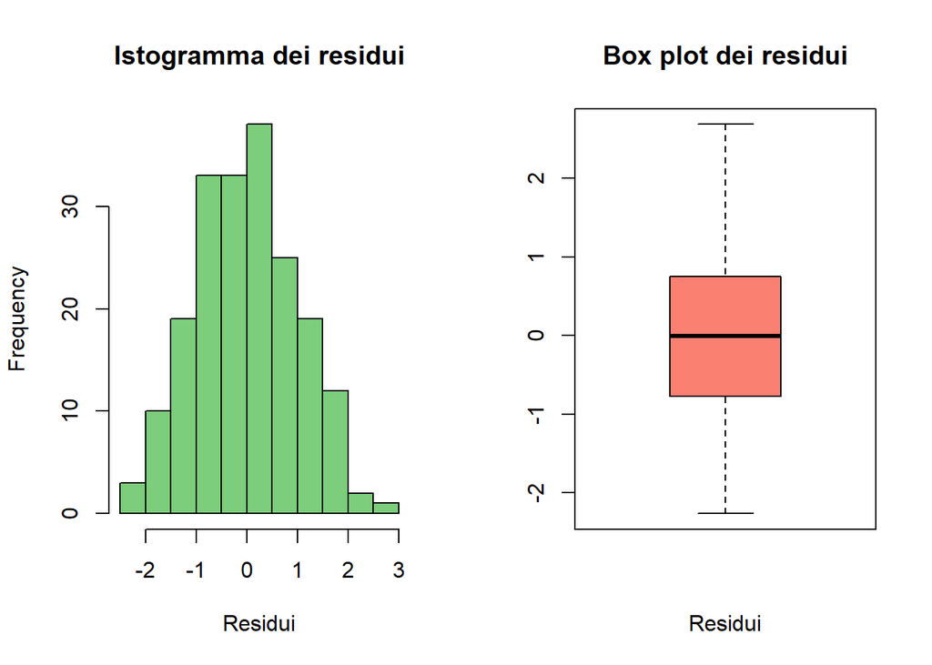

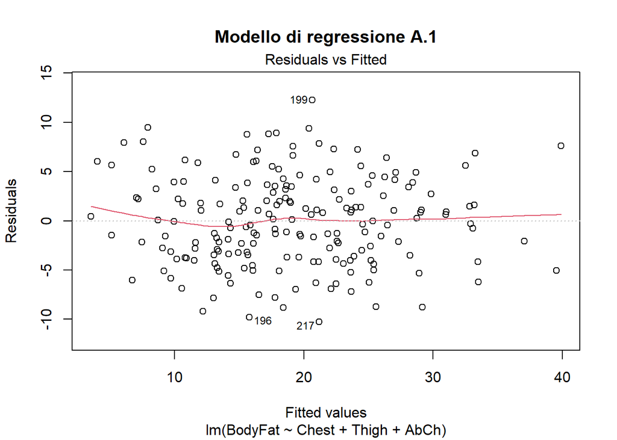

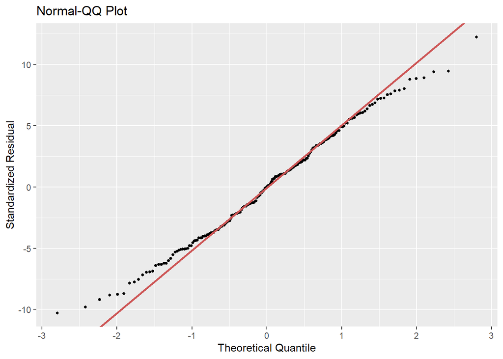

Il grafico di dispersione dei residui presenta un andamento regolare intorno allo 0, mostrando una relazione di tipo lineare. Ciò non suggerisce quindi l’introduzione di un termine, ad esempio, quadratico o cubico.

Il diagramma quantile-quantile invece presenta una retta che segue l’andamento dei punti rappresentanti i residui standardizzati, eccezion fatta per le code, presso cui i punti si allontanano moderatamente dalla retta.

Proviamo dunque a migliorare il modello mediante l’aggiunta di un’ulteriore covariata, scelta tra *Neck*, *Knee* e *Biceps*:

```
## Analysis of Variance Table
##
## Model 1: BodyFat ~ Chest + Thigh + AbCh
## Model 2: BodyFat ~ Chest + Thigh + AbCh + Neck
##   Res.Df    RSS Df Sum of Sq      F   Pr(>F)
## 1    191 3998.0
## 2    190 3795.8  1    202.13 10.118 0.001715 **
## ---
## Signif. codes:  0 '***' 0.001 '**' 0.01 '*' 0.05 '.' 0.1 ' ' 1
```

```
## Analysis of Variance Table
##
## Model 1: BodyFat ~ Chest + Thigh + AbCh
## Model 2: BodyFat ~ Chest + Thigh + AbCh + Knee
##   Res.Df    RSS Df Sum of Sq      F  Pr(>F)
## 1    191 3998.0
## 2    190 3906.2  1    91.758 4.4632 0.03594 *
## ---
## Signif. codes:  0 '***' 0.001 '**' 0.01 '*' 0.05 '.' 0.1 ' ' 1
```

```
## Analysis of Variance Table
##
## Model 1: BodyFat ~ Chest + Thigh + AbCh
## Model 2: BodyFat ~ Chest + Thigh + AbCh + Biceps
##   Res.Df    RSS Df Sum of Sq      F Pr(>F)
## 1    191 3998.0
## 2    190 3995.2  1    2.7986 0.1331 0.7156
```

Dall’analisi delle tabelle, *Neck* risulta la covariata più significativa da aggiungere. Aggiungiamo dunque *Neck* e vediamo se è possibile migliorare ulteriormente il modello tramite l’aggiunta dell’altra covariata significativa, ovvero *Knee*.

```
## Analysis of Variance Table
##
## Model 1: BodyFat ~ Chest + Thigh + AbCh + Neck
## Model 2: BodyFat ~ Chest + Thigh + AbCh + Neck + Knee
##   Res.Df    RSS Df Sum of Sq      F  Pr(>F)
## 1    190 3795.8
## 2    189 3739.8  1    56.049 2.8326 0.09402 .
## ---
## Signif. codes:  0 '***' 0.001 '**' 0.01 '*' 0.05 '.' 0.1 ' ' 1
```

```
##
## Call:
## lm(formula = BodyFat ~ Chest + Thigh + AbCh + Neck + Knee, data = bodyfat.train.1)
##
## Residuals:
##     Min      1Q  Median      3Q     Max
## -9.7937 -3.0974 -0.0233  2.9785 12.7450
##
## Coefficients:
##               Estimate Std. Error t value Pr(>|t|)
## (Intercept) -101.63461    7.33006 -13.865  < 2e-16 ***
## Chest          0.76661    0.06732  11.388  < 2e-16 ***
## Thigh         -0.05670    0.11675  -0.486  0.62778
## AbCh          94.72244    8.03418  11.790  < 2e-16 ***
## Neck          -0.66732    0.23010  -2.900  0.00417 **
## Knee          -0.38068    0.22619  -1.683  0.09402 .
## ---
## Signif. codes:  0 '***' 0.001 '**' 0.01 '*' 0.05 '.' 0.1 ' ' 1
##
## Residual standard error: 4.448 on 189 degrees of freedom
## Multiple R-squared:  0.7335, Adjusted R-squared:  0.7264
## F-statistic:   104 on 5 and 189 DF,  p-value: < 2.2e-16
```

Come si evince dalla tabella, la covariata *Thigh* non risulta più significativa. Rimuoviamola ed analizziamo il modello.

```
##
## Call:
## lm(formula = BodyFat ~ Chest + AbCh + Neck + Knee, data = bodyfat.train.1)
##
## Residuals:
##     Min      1Q  Median      3Q     Max
## -9.8695 -3.0646 -0.0182  3.0634 12.7538
##
## Coefficients:
##               Estimate Std. Error t value Pr(>|t|)
## (Intercept) -100.65800    7.03462 -14.309  < 2e-16 ***
## Chest          0.75905    0.06536  11.613  < 2e-16 ***
## AbCh          93.91523    7.84454  11.972  < 2e-16 ***
## Neck          -0.68781    0.22575  -3.047  0.00264 **
## Knee          -0.43412    0.19722  -2.201  0.02893 *
## ---
## Signif. codes:  0 '***' 0.001 '**' 0.01 '*' 0.05 '.' 0.1 ' ' 1
##
## Residual standard error: 4.439 on 190 degrees of freedom
## Multiple R-squared:  0.7332, Adjusted R-squared:  0.7275
## F-statistic: 130.5 on 4 and 190 DF,  p-value: < 2.2e-16
```

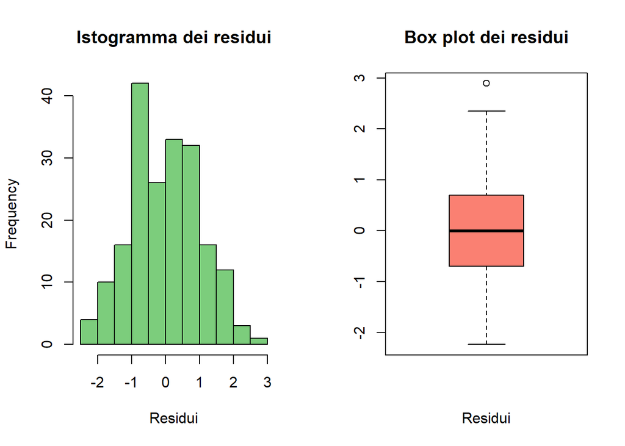

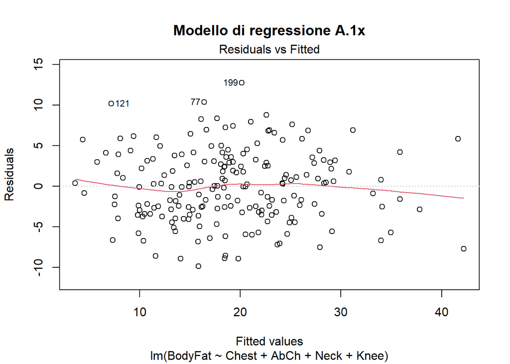

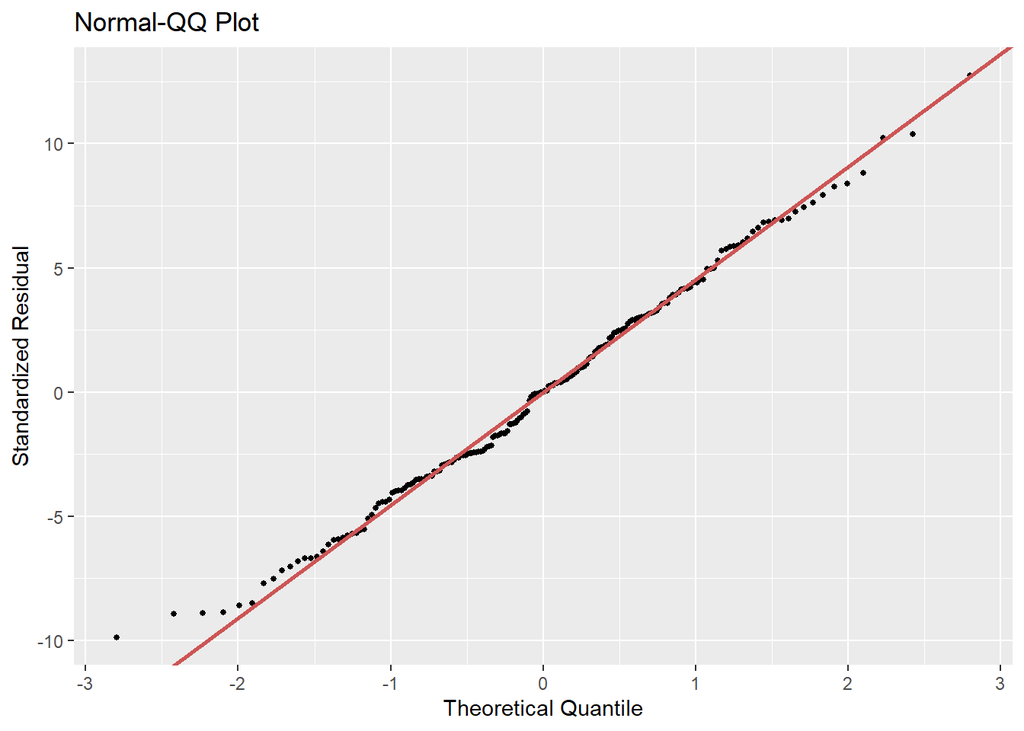

Il diagramma quantile-quantile risulta leggermente più fedele alla retta nei pressi delle code. Tuttavia, analizzando il grafico dei residui, notiamo la presenza di diversi valori anomali che fanno divergere l’andamento della curva dallo zero. Rimuoviamoli e fittiamo di nuovo il modello.

```
##
## Call:
## lm(formula = BodyFat ~ Neck + Chest + Knee + AbCh, data = bodyfat.train.1)
##
## Residuals:
##     Min      1Q  Median      3Q     Max
## -9.7078 -3.0456  0.0737  3.1046 12.8516
##
## Coefficients:
##               Estimate Std. Error t value Pr(>|t|)
## (Intercept) -101.47703    7.09433 -14.304  < 2e-16 ***
## Neck          -0.67502    0.22711  -2.972  0.00335 **
## Chest          0.75308    0.06527  11.538  < 2e-16 ***
## Knee          -0.43525    0.19650  -2.215  0.02798 *
## AbCh          94.84091    7.86836  12.053  < 2e-16 ***
## ---
## Signif. codes:  0 '***' 0.001 '**' 0.01 '*' 0.05 '.' 0.1 ' ' 1
##
## Residual standard error: 4.407 on 185 degrees of freedom
## Multiple R-squared:  0.7397, Adjusted R-squared:  0.7341
## F-statistic: 131.4 on 4 and 185 DF,  p-value: < 2.2e-16
```

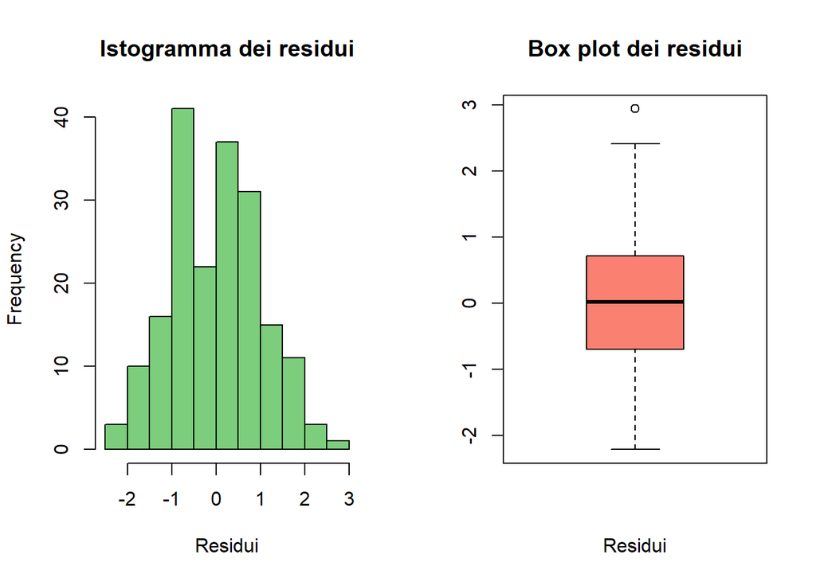

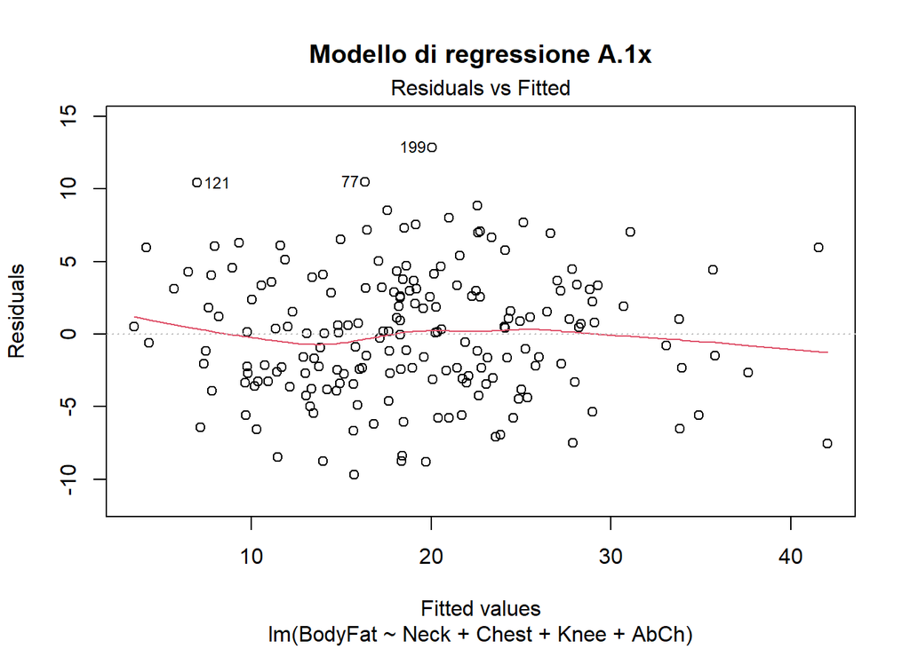

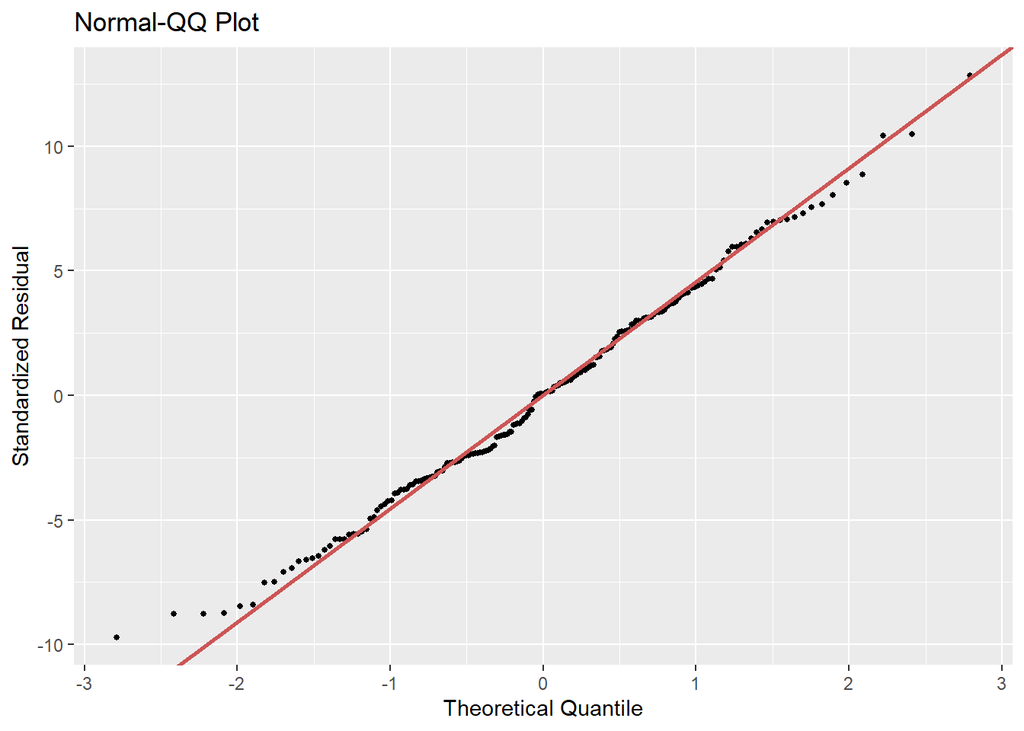

# 5 PREDIZIONE E CONFRONTO CON DENSITA’

## 5.1 PREDIZIONE

Verifichiamo la percentuale di valori “correttamente” predetti con cinque diverse percentuali di margine, i.e. l’errore tollerato. Successivamente grafichiamo la differenza, in valore assoluto, tra valori predetti e valori reali.

```
## [1] "Valori correttamente predetti con il 25 % di margine:"
## [1] "41/50"
## [1] "Percentuale: 82"
```

```
## [1] "Valori correttamente predetti con il 20 % di margine:"
## [1] "40/50"
## [1] "Percentuale: 80"
```

```
## [1] "Valori correttamente predetti con il 15 % di margine:"
## [1] "40/50"
## [1] "Percentuale: 80"
```

```
## [1] "Valori correttamente predetti con il 10 % di margine:"
## [1] "38/50"
## [1] "Percentuale: 76"
```

```
## [1] "Valori correttamente predetti con il 5 % di margine:"
## [1] "35/50"
## [1] "Percentuale: 70"
```

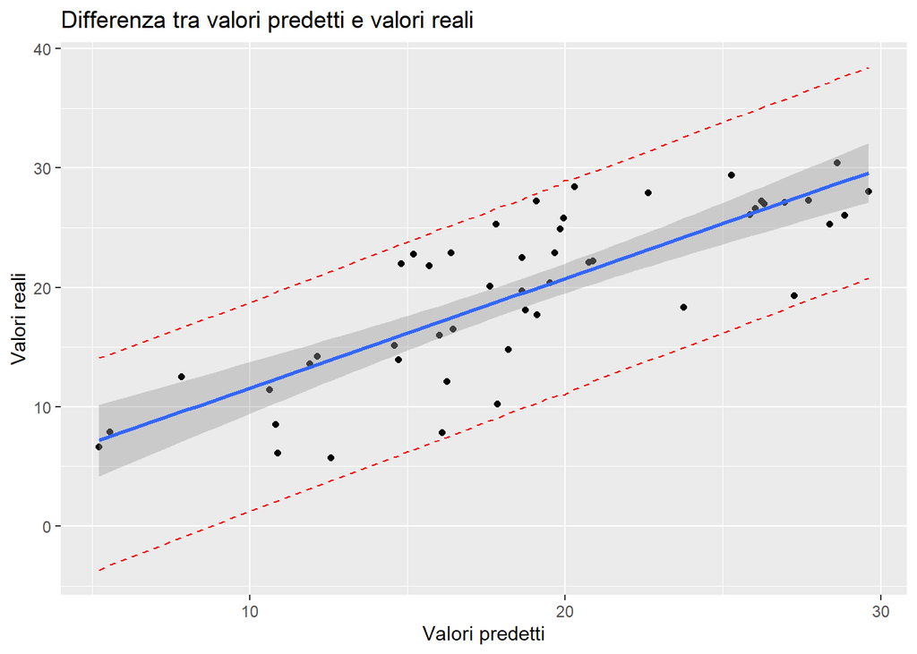

Le linee rosse tratteggiate rappresentano gli estremi dell’intervallo di predizione, i.e. l’incertezza intorno ai singoli valori predetti. La banda intorno alla linea di regressione (in blu) rappresenta invece l’incertezza intorno alle previsioni medie. In entrambi i casi, il livello di confidenza/tolleranza è del 95%.

## 5.2 CONFRONTO CON DENSITA’

Anche per il modello avente come unica covariata la variabile *Density* effettuiamo una selezione in fase di regressione, in modo da garantire la parità di condizioni con il modello precedentemente costruito.

```
##
## Call:
## lm(formula = BodyFat ~ Density, data = bodyfat.train.density)
##
## Residuals:
##      Min       1Q   Median       3Q      Max
## -1.51862 -0.11566 -0.05211  0.10199  1.43879
##
## Coefficients:
##              Estimate Std. Error t value Pr(>|t|)
## (Intercept)  489.1647     0.9095   537.9   <2e-16 ***
## Density     -445.3302     0.8613  -517.0   <2e-16 ***
## ---
## Signif. codes:  0 '***' 0.001 '**' 0.01 '*' 0.05 '.' 0.1 ' ' 1
##
## Residual standard error: 0.229 on 193 degrees of freedom
## Multiple R-squared:  0.9993, Adjusted R-squared:  0.9993
## F-statistic: 2.673e+05 on 1 and 193 DF,  p-value: < 2.2e-16
```

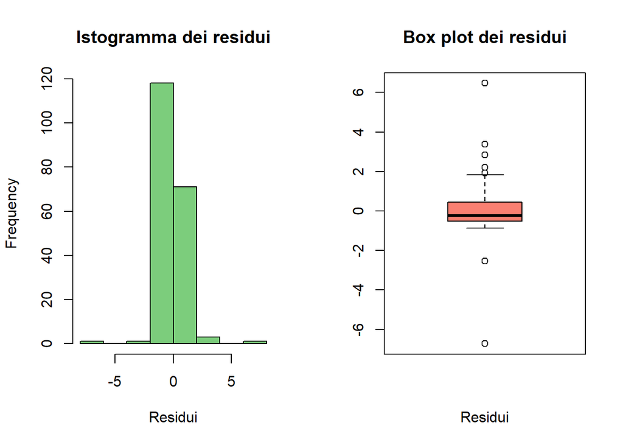

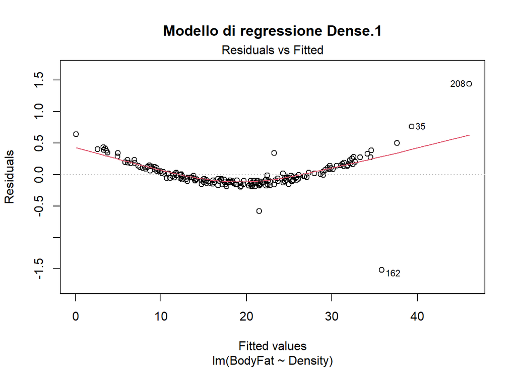

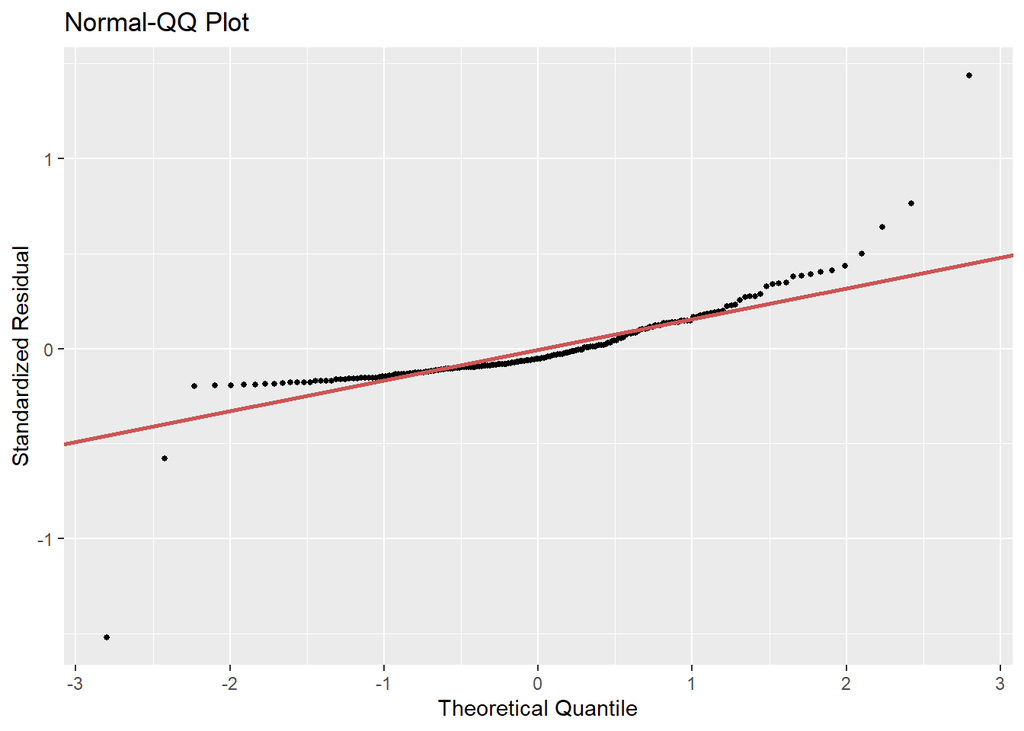

L’indice R-quadro è molto alto, tuttavia, analizzando il diagramma di dispersione dei residui, notiamo un andamento leggermente parabolico. Proviamo dunque ad aggiungere un termine quadratico.

```
##
## Call:
## lm(formula = BodyFat ~ Density + I(Density^2), data = bodyfat.train.density)
##
## Residuals:
##      Min       1Q   Median       3Q      Max
## -1.86579 -0.02473  0.00524  0.03719  0.45605
##
## Coefficients:
##              Estimate Std. Error t value Pr(>|t|)
## (Intercept)    908.98      26.00   34.96   <2e-16 ***
## Density      -1242.32      49.35  -25.18   <2e-16 ***
## I(Density^2)   378.14      23.41   16.15   <2e-16 ***
## ---
## Signif. codes:  0 '***' 0.001 '**' 0.01 '*' 0.05 '.' 0.1 ' ' 1
##
## Residual standard error: 0.1495 on 192 degrees of freedom
## Multiple R-squared:  0.9997, Adjusted R-squared:  0.9997
## F-statistic: 3.138e+05 on 2 and 192 DF,  p-value: < 2.2e-16
```